# Exploratory Analysis Milestone Report week2

yusue

3/19/2020

# Introduction

This is the milestone report for the Exploratory Analysis section of the Coursera Data Science Capstone project. The goal of the capstone project is to build an application based on a predictive text model. The user will provide a word or a phrase and the application will try to predict the next word. The model will be trained using a corpus (a collection of English text) that is compiled from 3 sources - news, blogs, and tweets.

In the following report, I first did an overview statistics for the data. Second, I created a sample for each of the file to reduce run time and then merge 3 samples as the training dataset. Third, I created a corpus and do necessary cleaning with quanteda package. Forth, I tokenized ngrams using the functions in quanteda package. Last, I did exploratory analysis using ggplot2 package to visualize the results.

## Load data and packages

1. load the required libraries and set up the work environment.

```r
library(tm)
library(NLP)
library(stringi)
library(tokenizers)
library(quanteda)
```

```r
library(ggplot2)
```

2. Read text files

```r
setwd("/Users/yusue/Downloads/final/en_US")
twitter <-readLines("en_US.twitter.txt", encoding = "UTF-8",skipNul = TRUE)
news <- readLines("en_US.news.txt", encoding = 'UTF-8',skipNul = TRUE)
blogs <- readLines("en_US.blogs.txt", encoding = 'UTF-8', skipNul = TRUE)
```

## Overview of the data

To get a sense of what the data looks like, I summerized the main information from each of the 3 datasets (Blog, News and Twitter). I checked lines, file size, words counts in each file.

```r
 overview = data.frame(
   fileName = c("twitter","news","blogs"),
    fileSize = sapply(list(twitter,news,blogs), function(x){format(object.size(x),"Mb")}),
    t(rbind(sapply(list(twitter,news,blogs),stri_stats_general),
    wordcount=sapply(list(twitter,news,blogs),stri_stats_latex)[4,])
    )
   )
overview
```

```
##   fileName fileSize   Lines LinesNEmpty     Chars CharsNWhite wordcount
## 1  twitter   319 Mb 2360148     2360148 162096241   134082806  30451170
## 2     news 257.3 Mb 1010242     1010242 203223154   169860866  34494539
## 3    blogs 255.4 Mb  899288      899288 206824382   170389539  37570839
```

As we can see, the size of each file is more than 200Mb, which is very big. To reduce runing time, we have to subset data for sampling.

## Sampling and combing data

```r
set.seed(1234)
twitter_subset= sample(twitter,length(twitter)*0.05)
news_subset=sample(news,length(news)*0.05)
blogs_subset=sample(blogs,length(blogs)*0.05)

dataset=c(twitter_subset,news_subset,blogs_subset)
dataset = iconv(dataset,"UTF-8","ASCII", sub = "")
```

## Creating and cleaning corpus using quanteda

```r
quanteda_corp = corpus(dataset)
corpus_token<-tokens(quanteda_corp,
                     remove_punct = TRUE,
                     remove_symbols = TRUE,
                     remove_numbers = TRUE,
                     remove_url = TRUE)
corpus_tokens=tokens_remove(corpus_token, stopwords("english"))
```

## Create ngrams and calculate frequency using quanteda

Now that we have created and cleaned the corpus we will be able to look at the distribution of various n-grams. First, let us do unigrams after creating the tokenization, which followed by a plot for visualization.

```r
uni_ngrams = tokens_ngrams(corpus_token, n=1)
dfmat1 = dfm(uni_ngrams)
uni_freq=textstat_frequency(dfmat1)
head(uni_freq)
```

```
##   feature frequency rank docfreq group
## 1     the    236988    1  101493   all
## 2      to    137404    2   81584   all
## 3     and    119060    3   69304   all
## 4       a    117963    4   72061   all
## 5      of    100127    5   60101   all
## 6       i     82538    6   47854   all
```

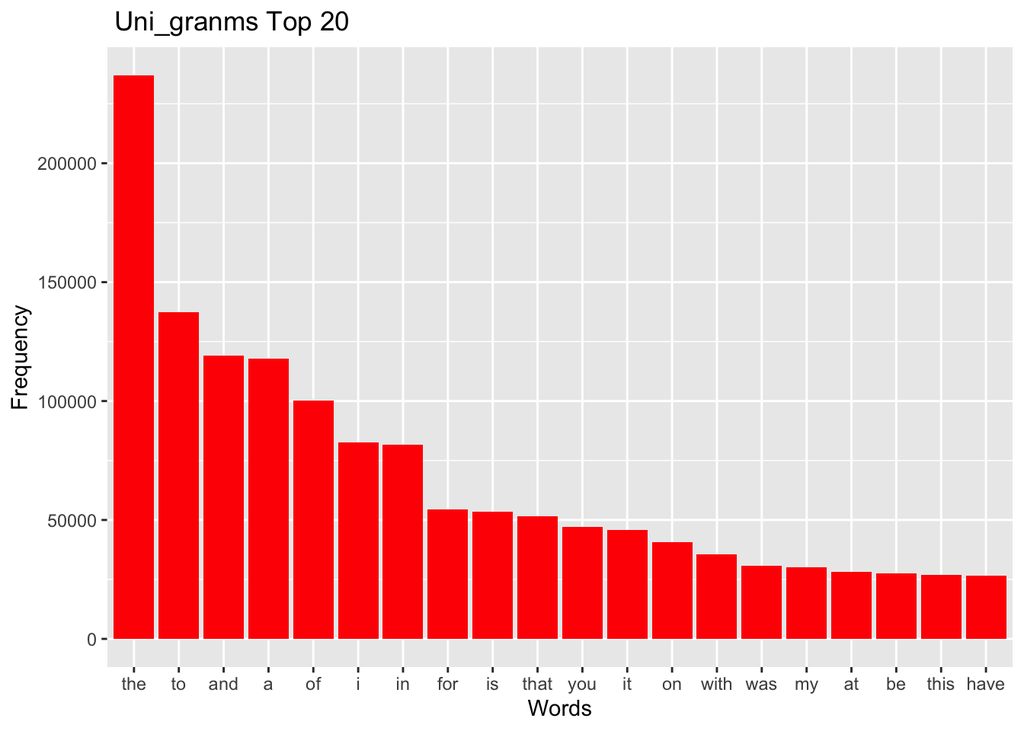

```r
# plot 20 most frequent single words
ggplot(uni_freq[1:20, ], aes(x = reorder(feature, -frequency), y = frequency)) +
    geom_bar(stat="identity", fill="red") +
    ggtitle(" Uni_granms Top 20") +
    labs(x = "Words", y = "Frequency")
```

Then we will do the same for the bingrams and tringrams.

```r
bi_ngrams = tokens_ngrams(corpus_token, n=2)
dfmat2 = dfm(bi_ngrams)
bi_freq=textstat_frequency(dfmat2)
head(bi_freq)
```

```
##   feature frequency rank docfreq group
## 1  of_the     21445    1   17680   all
## 2  in_the     20249    2   17528   all
## 3  to_the     10535    3    9679   all
## 4 for_the     10059    4    9503   all
## 5  on_the      9641    5    8910   all
## 6   to_be      8150    6    7443   all
```

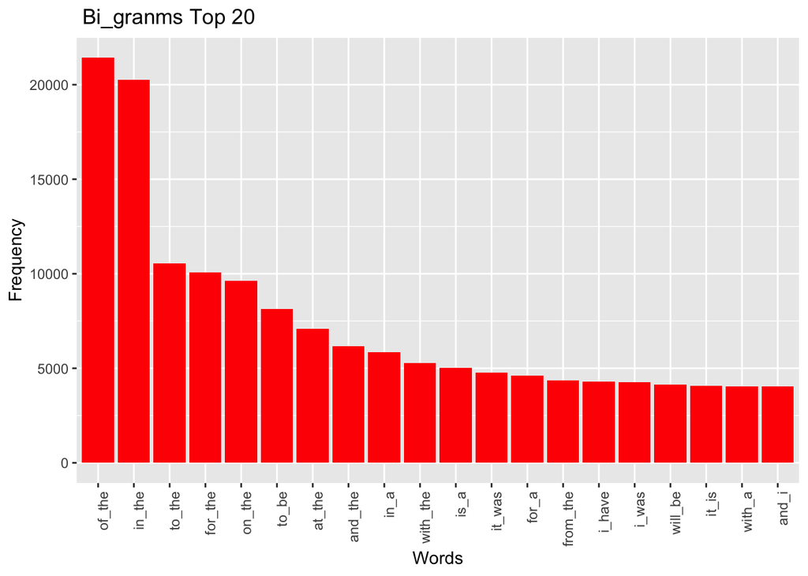

```r
ggplot(bi_freq[1:20, ], aes(x = reorder(feature, -frequency), y = frequency)) +
    geom_bar(stat="identity", fill="red") +
    ggtitle(" Bi_granms Top 20") +
    labs(x = "Words", y = "Frequency")+
    theme(axis.text.x=element_text(angle=90, hjust=1))
```

```r
tri_ngrams = tokens_ngrams(corpus_token, n=3)
dfmat3 = dfm(tri_ngrams)
tri_freq=textstat_frequency(dfmat3)
head(tri_freq)
```

```
##          feature frequency rank docfreq group
## 1     one_of_the      1744    1    1697   all
## 2       a_lot_of      1523    2    1431   all
## 3 thanks_for_the      1251    3    1250   all
## 4        to_be_a       895    4     873   all
## 5    going_to_be       882    5     830   all
## 6     out_of_the       776    6     754   all
```

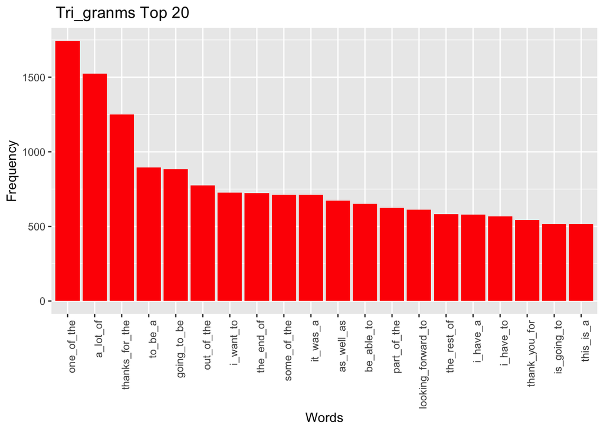

```r
ggplot(tri_freq[1:20, ], aes(x = reorder(feature, -frequency), y = frequency)) +
    geom_bar(stat="identity", fill="red") +
    ggtitle(" Tri_granms Top 20") +
    labs(x = "Words", y = "Frequency")+
    theme(axis.text.x=element_text(angle=90, hjust=1))
```

## Wordcloud We can also do a wordcloud to see the most common words quickly.

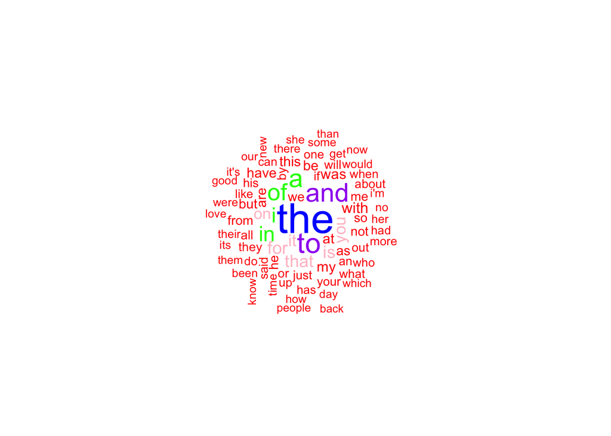

```r
set.seed(100)
textplot_wordcloud(dfmat1, min_count =10, min_size=1, max_words = 80,
color = c('red', 'pink', 'green', 'purple', 'orange', 'blue'))
```

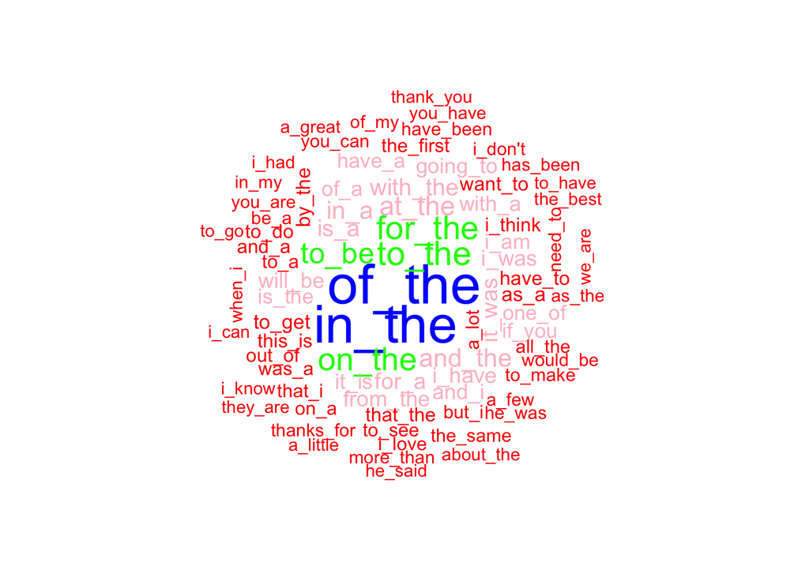

```r
textplot_wordcloud(dfmat2, min_count =10, min_size=1, max_words = 80,
color = c('red', 'pink', 'green', 'purple', 'orange', 'blue'))
```

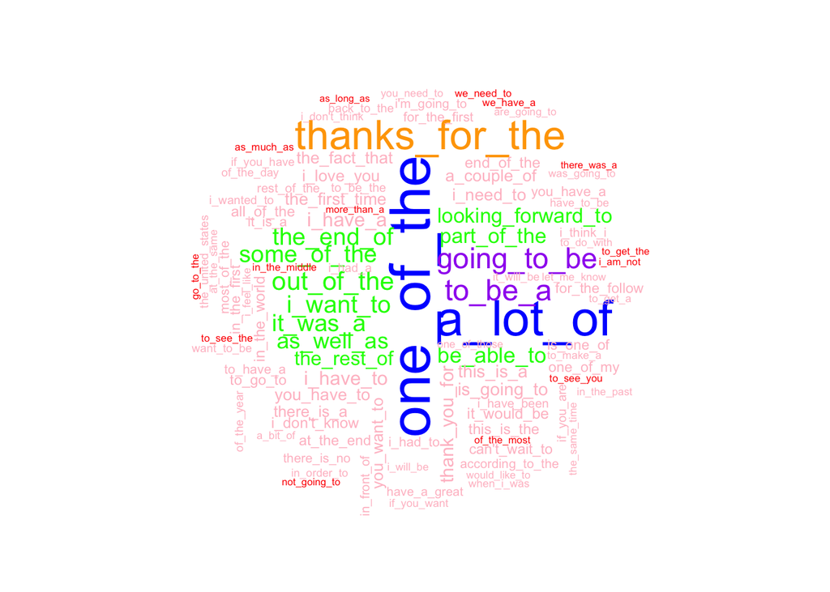

```r
textplot_wordcloud(dfmat3, min_count =10, min_size=0.1, max_words = 100,random.order=FALSE,
color = c('red', 'pink', 'green', 'purple', 'orange', 'blue'))
```